# DataAnalysis

## Real-world Data Wrangling

In this project, you will apply the skills you acquired in the course to gather and wrangle real-world data with two datasets of your choice.

### 1. Gather data

### **1.1.** Problem Statement

- Google Dataset Search https://datasetsearch.research.google.com/
- The U.S. Government’s open data https://data.gov/
- UCI Machine Learning Repository https://archive.ics.uci.edu/ml/index.php

```python
# Importing the numpy library
import numpy as np

# Importing the pandas library
import pandas as pd

# Importing the matplotlib library
from matplotlib import pyplot as plt

# Importing the zipfile library
import zipfile

# Importing the os library
import os

# Importing the seaborn library
import seaborn as sns

# Ensuring that matplotlib plots display inline within Jupyter Notebooks
%matplotlib inline
```

#### **Dataset 1**

Type: CSV File.

Method: The data was gathered using the "Downloading files" method from https://archive.ics.uci.edu/ source.)

Dataset variables:

- age: Age of the individual.
- workclass: The type of work the individual is engaged in (e.g., private, self-employed, government).
- fnlwgt: Final weight assigned to each individual in the dataset.
- education: Highest level of education
- education-num: Number of years of education
- marital-status: Marital status of the individual (e.g., married, single, divorced).
- relationship: Relationship status(e.g., husband, wife, own-child, Not-in-family, Unmarried, etc).
- race: (e.g., White, Black, Asian-Pac-Islander, Amer-Indian-Eskimo)
- sex: Gender (e.g., Male, Female).
- capital-gain: Capital gains
- capital-loss: Capital-loss
- hours-per-week: Number of hours worked per week.
- native-country: Country of origin of the individual.
- annual_income: Annual income (e.g., <=50K, >50K).

```python
# Load the dataset
df1 = pd.read_csv('census-income .csv')

# Display the first 10 rows
print(df1.head(10))
```

```
   age         workclass  fnlwgt  education  education-num  \
0   39         State-gov   77516  Bachelors             13
1   50  Self-emp-not-inc   83311  Bachelors             13
2   38           Private  215646    HS-grad              9
3   53           Private  234721       11th              7
4   28           Private  338409  Bachelors             13
5   37           Private  284582    Masters             14
6   49           Private  160187        9th              5
7   52  Self-emp-not-inc  209642    HS-grad              9
8   31           Private   45781    Masters             14
9   42           Private  159449  Bachelors             13

          marital-status         occupation   relationship   race     sex  \
0          Never-married       Adm-clerical  Not-in-family  White    Male
1     Married-civ-spouse    Exec-managerial        Husband  White    Male
```

[output cut: 20 more lines]

```python
# Basic info about the DataFrame
df1.info()

# Check for missing values
print(df1.isnull().sum())
```

```
<class 'pandas.core.frame.DataFrame'>
RangeIndex: 32561 entries, 0 to 32560
Data columns (total 15 columns):
 #   Column          Non-Null Count  Dtype
---  ------          --------------  -----
 0   age             32561 non-null  int64
 1   workclass       32561 non-null  object
 2   fnlwgt          32561 non-null  int64
 3   education       32561 non-null  object
 4   education-num   32561 non-null  int64
 5   marital-status  32561 non-null  object
 6   occupation      32561 non-null  object
 7   relationship    32561 non-null  object
 8   race            32561 non-null  object
 9   sex             32561 non-null  object
 10  capital-gain    32561 non-null  int64
 11  capital-loss    32561 non-null  int64
 12  hours-per-week  32561 non-null  int64
 13  native-country  32561 non-null  object
 14  annual_income   32561 non-null  object
dtypes: int64(6), object(9)
memory usage: 3.7+ MB
age               0
workclass         0
fnlwgt            0
education         0
education-num     0
marital-status    0
occupation        0
relationship      0
race              0
sex               0
capital-gain      0
capital-loss      0
hours-per-week    0
native-country    0
annual_income     0
dtype: int64
```

```python
# Descriptive statistics
print(df1.describe())
```

```
                age        fnlwgt  education-num  capital-gain  capital-loss  \
count  32561.000000  3.256100e+04   32561.000000  32561.000000  32561.000000
mean      38.581647  1.897784e+05      10.080679   1077.648844     87.303830
std       13.640433  1.055500e+05       2.572720   7385.292085    402.960219
min       17.000000  1.228500e+04       1.000000      0.000000      0.000000
25%       28.000000  1.178270e+05       9.000000      0.000000      0.000000
50%       37.000000  1.783560e+05      10.000000      0.000000      0.000000
75%       48.000000  2.370510e+05      12.000000      0.000000      0.000000
max       90.000000  1.484705e+06      16.000000  99999.000000   4356.000000

       hours-per-week
count    32561.000000
mean        40.437456
std         12.347429
min          1.000000
25%         40.000000
50%         40.000000
75%         45.000000
max         99.000000
```

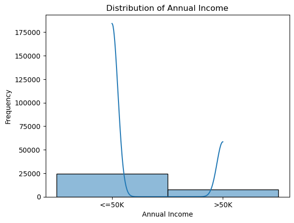

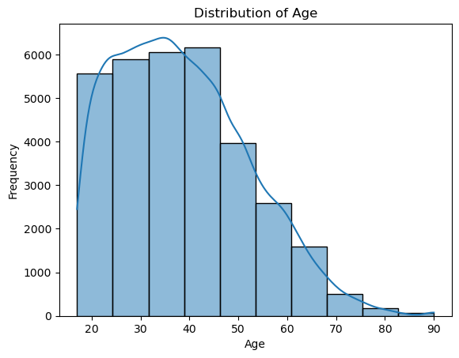

```python
import matplotlib.pyplot as plt
import seaborn as sns

sns.histplot(df1['annual_income'], bins=30, kde=True)
plt.title('Distribution of Annual Income')
plt.xlabel('Annual Income')
plt.ylabel('Frequency')
plt.show()

sns.histplot(df1['age'], bins=10, kde=True)
plt.title('Distribution of Age')
plt.xlabel('Age')
plt.ylabel('Frequency')
plt.show()
```

```python
# Check for invalid values in 'age'
invalid_ages = df1[df1['age'] < 0]
print(f"Invalid ages found: {invalid_ages}")
```

```
Invalid ages found: Empty DataFrame
Columns: [age, workclass, fnlwgt, education, education-num, marital-status, occupation, relationship, race, sex, capital-gain, capital-loss, hours-per-week, native-country, annual_income]
Index: []
```

Method: This dataset was programmatically downloaded using the Kaggle API.

The source: https://www.kaggle.com/datasets/sonia22222/students-mental-health-assessments/data

Dataset variables:

Age

Course: student's major or field of study.

Gender

CGPA: Cumulative Grade Point Average.

Stress_Level: The level of stress experienced by the individual.

Depression_Score: The score representing the level of depression experienced by the individual.

Anxiety_Score: The score representing the level of anxiety experienced by the individual.

Sleep_Quality: The quality of sleep experienced by the individual .

Physical_Activity: The level of physical activity .

Diet_Quality: The quality of the individual's diet.

Social_Support: The level of social support received by the individual.

Substance_Use: The frequency of substance use such as alcohol, cigarettes or other drugs.

Counseling_Service_Use: refers to whether or not the student has utilized counseling services provided by their educational institution.

Family_History: Whether the individual has a family history of mental health issues.

Financial_Stress

Extracurricular_Involvement

Semester_Credit_Load: The number of credits the individual is taking in the semester (15-30).

Residence_Type: on or off campus.

```python
!pip install kaggle
```

```python
!kaggle datasets download -d sonia22222/students-mental-health-assessments
```

```
Dataset URL: https://www.kaggle.com/datasets/sonia22222/students-mental-health-assessments
License(s): CC0-1.0
students-mental-health-assessments.zip: Skipping, found more recently modified local copy (use --force to force download)
```

```python
zip_file_path = 'students-mental-health-assessments.zip'

# Define the directory to extract files to
extract_to_path = 'Desktop/'

# Ensure the extraction directory exists
os.makedirs(extract_to_path, exist_ok=True)

# Open the ZIP file
with zipfile.ZipFile(zip_file_path, 'r') as zip_ref:
    # Extract all contents to the specified directory
    zip_ref.extractall(extract_to_path)

print(f'Files extracted to: {extract_to_path}')
```

```
Files extracted to: Desktop/
```

```python
# Dataset 2:
students_df = pd.read_csv('Desktop/students_mental_health_survey.csv')
students_df.head()
```

|  | Age | Course | Gender | CGPA | Stress_Level | Depression_Score | Anxiety_Score | Sleep_Quality | Physical_Activity | Diet_Quality | Social_Support | Relationship_Status | Substance_Use | Counseling_Service_Use | Family_History | Chronic_Illness | Financial_Stress | Extracurricular_Involvement | Semester_Credit_Load | Residence_Type |
| --- | --- | --- | --- | --- | --- | --- | --- | --- | --- | --- | --- | --- | --- | --- | --- | --- | --- | --- | --- | --- |
| 0 | 25 | Others | Male | 3.56 | 3 | 3 | 2 | Good | Moderate | Good | Moderate | Married | Never | Never | No | No | 2 | Moderate | 17 | On-Campus |
| 1 | 24 | Engineering | Female | 2.44 | 0 | 3 | 0 | Average | Low | Average | Low | Single | Occasionally | Occasionally | No | No | 3 | Low | 27 | On-Campus |
| 2 | 19 | Business | Female | 3.74 | 4 | 0 | 3 | Good | Low | Average | Moderate | In a Relationship | Never | Occasionally | No | No | 4 | High | 15 | On-Campus |
| 3 | 19 | Computer Science | Male | 3.65 | 2 | 1 | 0 | Average | Low | Average | Moderate | Single | NaN | Never | No | No | 4 | Moderate | 20 | Off-Campus |
| 4 | 18 | Business | Male | 3.40 | 3 | 3 | 4 | Good | Low | Average | High | Married | Never | Never | No | Yes | 0 | High | 23 | On-Campus |

```python
# Basic info about the DataFrame
students_df.info()
# Check for missing values
print(students_df.isnull().sum())
# Descriptive statistics
print(students_df.describe())
```

```
<class 'pandas.core.frame.DataFrame'>
RangeIndex: 7022 entries, 0 to 7021
Data columns (total 20 columns):
 #   Column                       Non-Null Count  Dtype
---  ------                       --------------  -----
 0   Age                          7022 non-null   int64
 1   Course                       7022 non-null   object
 2   Gender                       7022 non-null   object
 3   CGPA                         7010 non-null   float64
 4   Stress_Level                 7022 non-null   int64
 5   Depression_Score             7022 non-null   int64
 6   Anxiety_Score                7022 non-null   int64
 7   Sleep_Quality                7022 non-null   object
 8   Physical_Activity            7022 non-null   object
 9   Diet_Quality                 7022 non-null   object
 10  Social_Support               7022 non-null   object
 11  Relationship_Status          7022 non-null   object
 12  Substance_Use                7007 non-null   object
 13  Counseling_Service_Use       7022 non-null   object
 14  Family_History               7022 non-null   object
 15  Chronic_Illness              7022 non-null   object
 16  Financial_Stress             7022 non-null   int64
 17  Extracurricular_Involvement  7022 non-null   object
 18  Semester_Credit_Load         7022 non-null   int64
 19  Residence_Type               7022 non-null   object
dtypes: float64(1), int64(6), object(13)
memory usage: 1.1+ MB
Age                             0
Course                          0
Gender                          0
CGPA                           12
Stress_Level                    0
Depression_Score                0
Anxiety_Score                   0
Sleep_Quality                   0
Physical_Activity               0
Diet_Quality                    0
Social_Support                  0
Relationship_Status             0
Substance_Use                  15
```

[output cut: 12 more lines]

```
min      18.000000     2.44000      0.000000          0.000000       0.000000
25%      20.000000     3.29000      1.000000          1.000000       1.000000
50%      22.000000     3.50000      2.000000          2.000000       2.000000
75%      25.000000     3.70000      4.000000          3.000000       4.000000
max      35.000000     4.00000      5.000000          5.000000       5.000000

       Financial_Stress  Semester_Credit_Load
count       7022.000000           7022.000000
mean           2.453005             22.010538
std            1.708995              4.358380
min            0.000000             15.000000
25%            1.000000             18.000000
50%            2.000000             22.000000
75%            4.000000             26.000000
max            5.000000             29.000000
```

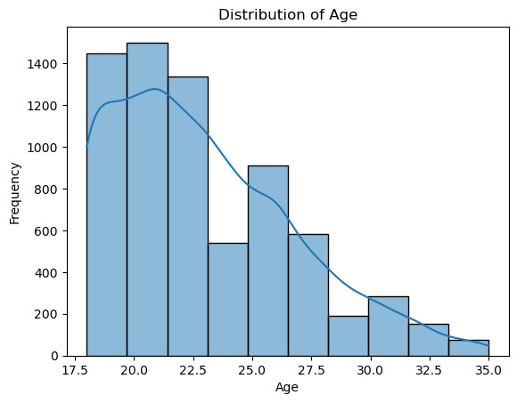

```python
sns.histplot(students_df['Age'], bins=10, kde=True)
plt.title('Distribution of Age')
plt.xlabel('Age')
plt.ylabel('Frequency')
plt.show()
```

```python
invalid_stu_ages = students_df[students_df['Age'] < 0]
print(f"Invalid ages found: {invalid_stu_ages}")
```

```
Invalid ages found: Empty DataFrame
Columns: [Age, Course, Gender, CGPA, Stress_Level, Depression_Score, Anxiety_Score, Sleep_Quality, Physical_Activity, Diet_Quality, Social_Support, Relationship_Status, Substance_Use, Counseling_Service_Use, Family_History, Chronic_Illness, Financial_Stress, Extracurricular_Involvement, Semester_Cre…
Index: []
```

### **Quality Issue 1: Missing Values & Duplicate rows**

```python
print(df1.info())
```

```
<class 'pandas.core.frame.DataFrame'>
RangeIndex: 32561 entries, 0 to 32560
Data columns (total 15 columns):
 #   Column          Non-Null Count  Dtype
---  ------          --------------  -----
 0   age             32561 non-null  int64
 1   workclass       32561 non-null  object
 2   fnlwgt          32561 non-null  int64
 3   education       32561 non-null  object
 4   education-num   32561 non-null  int64
 5   marital-status  32561 non-null  object
 6   occupation      32561 non-null  object
 7   relationship    32561 non-null  object
 8   race            32561 non-null  object
 9   sex             32561 non-null  object
 10  capital-gain    32561 non-null  int64
 11  capital-loss    32561 non-null  int64
 12  hours-per-week  32561 non-null  int64
 13  native-country  32561 non-null  object
 14  annual_income   32561 non-null  object
dtypes: int64(6), object(9)
memory usage: 3.7+ MB
None
```

```python
# Replace '?' with np.nan
df1.replace('?', np.nan, inplace=True)
missing = df1.isnull().sum()
print(missing)
```

```
age                  0
workclass         1836
fnlwgt               0
education            0
education-num        0
marital-status       0
occupation        1843
relationship         0
race                 0
sex                  0
capital-gain         0
capital-loss         0
hours-per-week       0
native-country     583
annual_income        0
dtype: int64
```

```python
duplicate_rows = df1.duplicated().sum()
print(f"Number of duplicate rows: {duplicate_rows}")
```

```
Number of duplicate rows: 24
```

##### Issue and justification: The columns `workclass`, `occupation`, and `native-country` have missing values. The initial .info() output doesn't account for placeholders like '?', which can hide missing data. Also there are duplicate rows.

### **Quality Issue 2: Missing Values**

```python
print(students_df.info())
```

```
<class 'pandas.core.frame.DataFrame'>
RangeIndex: 7022 entries, 0 to 7021
Data columns (total 20 columns):
 #   Column                       Non-Null Count  Dtype
---  ------                       --------------  -----
 0   Age                          7022 non-null   int64
 1   Course                       7022 non-null   object
 2   Gender                       7022 non-null   object
 3   CGPA                         7010 non-null   float64
 4   Stress_Level                 7022 non-null   int64
 5   Depression_Score             7022 non-null   int64
 6   Anxiety_Score                7022 non-null   int64
 7   Sleep_Quality                7022 non-null   object
 8   Physical_Activity            7022 non-null   object
 9   Diet_Quality                 7022 non-null   object
 10  Social_Support               7022 non-null   object
 11  Relationship_Status          7022 non-null   object
 12  Substance_Use                7007 non-null   object
 13  Counseling_Service_Use       7022 non-null   object
 14  Family_History               7022 non-null   object
 15  Chronic_Illness              7022 non-null   object
 16  Financial_Stress             7022 non-null   int64
 17  Extracurricular_Involvement  7022 non-null   object
 18  Semester_Credit_Load         7022 non-null   int64
 19  Residence_Type               7022 non-null   object
dtypes: float64(1), int64(6), object(13)
memory usage: 1.1+ MB
None
```

```python
missingdf2 = students_df.isnull().sum()
print(missingdf2)
```

```
Age                             0
Course                          0
Gender                          0
CGPA                           12
Stress_Level                    0
Depression_Score                0
Anxiety_Score                   0
Sleep_Quality                   0
Physical_Activity               0
Diet_Quality                    0
Social_Support                  0
Relationship_Status             0
Substance_Use                  15
Counseling_Service_Use          0
Family_History                  0
Chronic_Illness                 0
Financial_Stress                0
Extracurricular_Involvement     0
Semester_Credit_Load            0
Residence_Type                  0
dtype: int64
```

```python
duplicate_rows = students_df.duplicated().sum()
print(f"Number of duplicate rows: {duplicate_rows}")
```

```
Number of duplicate rows: 0
```

```python
invalid_age = students_df[(students_df['Age'] < 0) | (students_df['Age'] > 100)]
print("Invalid Age Values:\n", invalid_age)
```

```
Invalid Age Values:
 Empty DataFrame
Columns: [Age, Course, Gender, CGPA, Stress_Level, Depression_Score, Anxiety_Score, Sleep_Quality, Physical_Activity, Diet_Quality, Social_Support, Relationship_Status, Substance_Use, Counseling_Service_Use, Family_History, Chronic_Illness, Financial_Stress, Extracurricular_Involvement, Semester_Cre…
Index: []
```

```python
print("Unique Courses:\n", students_df['Course'].unique())
print("Unique Genders:\n", students_df['Gender'].unique())
```

```
Unique Courses:
 ['Others' 'Engineering' 'Business' 'Computer Science' 'Medical' 'Law']
Unique Genders:
 ['Male' 'Female']
```

```python
invalid_cgpa = students_df[(students_df['CGPA'] < 0) | (students_df['CGPA'] > 4)]
print("Invalid CGPA Values:\n", invalid_cgpa)
```

```
Invalid CGPA Values:
 Empty DataFrame
Columns: [Age, Course, Gender, CGPA, Stress_Level, Depression_Score, Anxiety_Score, Sleep_Quality, Physical_Activity, Diet_Quality, Social_Support, Relationship_Status, Substance_Use, Counseling_Service_Use, Family_History, Chronic_Illness, Financial_Stress, Extracurricular_Involvement, Semester_Cre…
Index: []
```

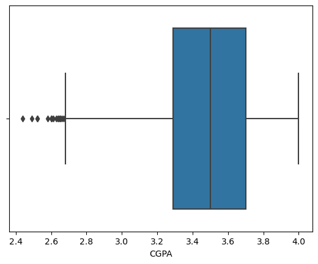

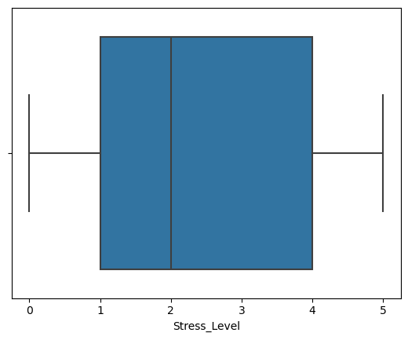

```python
import seaborn as sns
import matplotlib.pyplot as plt

sns.boxplot(x=students_df['CGPA'])
plt.show()

sns.boxplot(x=students_df['Stress_Level'])
plt.show()
```

##### Issue and justification:

###### Missing Values:

The columns `CGPA` and `Substance_Use` have missing values.

###### Duplicate Rows:

No duplicate rows found in the dataset.

###### Invalid Values:

- No invalid age values were found.
- No CGPA values were found to be less than 0 or greater than 4.

###### Inconsistent Values:

- Course: The unique courses listed are 'others', 'engineering', 'business', 'computer science', 'medical', and 'law'.
- Gender: Only 'Male' and 'Female' are present.

### **Tidiness Issue 1: Redundant Columns: `education` and `education-num` and Inconsistent Column Naming Conventions**

```python
#Data Types:
print(df1.dtypes)
```

```
age                int64
workclass         object
fnlwgt             int64
education         object
education-num      int64
marital-status    object
occupation        object
relationship      object
race              object
sex               object
capital-gain       int64
capital-loss       int64
hours-per-week     int64
native-country    object
annual_income     object
dtype: object
```

#### Check for Untidy Data Structure

```python
# Check if each variable has its own column
print("Columns in the dataset:", df1.columns)

# Ensure each row is a single observation
print("Number of rows and columns:", df1.shape)
```

```
Columns in the dataset: Index(['age', 'workclass', 'fnlwgt', 'education', 'education-num',
       'marital-status', 'occupation', 'relationship', 'race', 'sex',
       'capital-gain', 'capital-loss', 'hours-per-week', 'native-country',
       'annual_income'],
      dtype='object')
Number of rows and columns: (32561, 15)
```

#### Check for Columns Containing Multiple Variables

```python
# Print the first few rows to check for multiple variables in columns
print(df1.head())
```

```
   age         workclass  fnlwgt  education  education-num  \
0   39         State-gov   77516  Bachelors             13
1   50  Self-emp-not-inc   83311  Bachelors             13
2   38           Private  215646    HS-grad              9
3   53           Private  234721       11th              7
4   28           Private  338409  Bachelors             13

       marital-status         occupation   relationship   race     sex  \
0       Never-married       Adm-clerical  Not-in-family  White    Male
1  Married-civ-spouse    Exec-managerial        Husband  White    Male
2            Divorced  Handlers-cleaners  Not-in-family  White    Male
3  Married-civ-spouse  Handlers-cleaners        Husband  Black    Male
4  Married-civ-spouse     Prof-specialty           Wife  Black  Female

   capital-gain  capital-loss  hours-per-week native-country annual_income
0          2174             0              40  United-States         <=50K
1             0             0              13  United-States         <=50K
2             0             0              40  United-States         <=50K
3             0             0              40  United-States         <=50K
4             0             0              40           Cuba         <=50K
```

#### Check for Rows Containing Multiple Observations

```python
# Check for duplicated rows
duplicated_rows = df1.duplicated()
print(f"Number of duplicated rows: {duplicated_rows.sum()}")
```

```
Number of duplicated rows: 24
```

#### Check for Inconsistent Data Types

```python
# Check data types
print(students_df.dtypes)
```

```
Age                              int64
Course                          object
Gender                          object
CGPA                           float64
Stress_Level                     int64
Depression_Score                 int64
Anxiety_Score                    int64
Sleep_Quality                   object
Physical_Activity               object
Diet_Quality                    object
Social_Support                  object
Relationship_Status             object
Substance_Use                   object
Counseling_Service_Use          object
Family_History                  object
Chronic_Illness                 object
Financial_Stress                 int64
Extracurricular_Involvement     object
Semester_Credit_Load             int64
Residence_Type                  object
dtype: object
```

#### Check for Redundant Information

```python
# Checking for redundant columns (manual inspection based on column context)
print("Unique values per column to spot potential redundancy:")
for column in students_df.columns:
    print(f"{column}: {students_df[column].nunique()} unique values")
```

```
Unique values per column to spot potential redundancy:
Age: 18 unique values
Course: 6 unique values
Gender: 2 unique values
CGPA: 143 unique values
Stress_Level: 6 unique values
Depression_Score: 6 unique values
Anxiety_Score: 6 unique values
Sleep_Quality: 3 unique values
Physical_Activity: 3 unique values
Diet_Quality: 3 unique values
Social_Support: 3 unique values
Relationship_Status: 3 unique values
Substance_Use: 3 unique values
Counseling_Service_Use: 3 unique values
Family_History: 2 unique values
Chronic_Illness: 2 unique values
Financial_Stress: 6 unique values
Extracurricular_Involvement: 3 unique values
Semester_Credit_Load: 15 unique values
Residence_Type: 3 unique values
```

##### Issue and justification:

###### The dataset has two columns, "education" (which is categorical) and "education-num" (which is numerical), both representing the same information but in different formats. This redundancy violates the principle that each variable should be represented in a single column. Keeping both can lead to confusion and inconsistencies in data analysis and processing.

###### Also, columns like workclass, marital-status, occupation, relationship, race, sex, native-country, and annual_income are stored as object data types instead of categorical. This is not a direct violation of tidy data principles but affects the efficiency of data storage and manipulation.

### **Tidiness Issue 2: Inconsistent Categorical Encoding and Columns with Mixed Types of Information**

```python
# Basic info
print(students_df.info())
```

```
<class 'pandas.core.frame.DataFrame'>
RangeIndex: 7022 entries, 0 to 7021
Data columns (total 20 columns):
 #   Column                       Non-Null Count  Dtype
---  ------                       --------------  -----
 0   Age                          7022 non-null   int64
 1   Course                       7022 non-null   object
 2   Gender                       7022 non-null   object
 3   CGPA                         7010 non-null   float64
 4   Stress_Level                 7022 non-null   int64
 5   Depression_Score             7022 non-null   int64
 6   Anxiety_Score                7022 non-null   int64
 7   Sleep_Quality                7022 non-null   object
 8   Physical_Activity            7022 non-null   object
 9   Diet_Quality                 7022 non-null   object
 10  Social_Support               7022 non-null   object
 11  Relationship_Status          7022 non-null   object
 12  Substance_Use                7007 non-null   object
 13  Counseling_Service_Use       7022 non-null   object
 14  Family_History               7022 non-null   object
 15  Chronic_Illness              7022 non-null   object
 16  Financial_Stress             7022 non-null   int64
 17  Extracurricular_Involvement  7022 non-null   object
 18  Semester_Credit_Load         7022 non-null   int64
 19  Residence_Type               7022 non-null   object
dtypes: float64(1), int64(6), object(13)
memory usage: 1.1+ MB
None
```

#### Check for Untidy Data Structure

```python
# Check if each variable has its own column
print("Columns in the dataset:", students_df.columns)
# Ensure each row is a single observation
print("Number of rows and columns:", students_df.shape)
```

```
Columns in the dataset: Index(['Age', 'Course', 'Gender', 'CGPA', 'Stress_Level', 'Depression_Score',
       'Anxiety_Score', 'Sleep_Quality', 'Physical_Activity', 'Diet_Quality',
       'Social_Support', 'Relationship_Status', 'Substance_Use',
       'Counseling_Service_Use', 'Family_History', 'Chronic_Illness',
       'Financial_Stress', 'Extracurricular_Involvement',
       'Semester_Credit_Load', 'Residence_Type'],
      dtype='object')
Number of rows and columns: (7022, 20)
```

#### Check for Columns Containing Multiple Variables

```python
# Print the first few rows to check for multiple variables in columns
print(students_df.head())
```

```
   Age            Course  Gender  CGPA  Stress_Level  Depression_Score  \
0   25            Others    Male  3.56             3                 3
1   24       Engineering  Female  2.44             0                 3
2   19          Business  Female  3.74             4                 0
3   19  Computer Science    Male  3.65             2                 1
4   18          Business    Male  3.40             3                 3

   Anxiety_Score Sleep_Quality Physical_Activity Diet_Quality Social_Support  \
0              2          Good          Moderate         Good       Moderate
1              0       Average               Low      Average            Low
2              3          Good               Low      Average       Moderate
3              0       Average               Low      Average       Moderate
4              4          Good               Low      Average           High

  Relationship_Status Substance_Use Counseling_Service_Use Family_History  \
```

[output cut: 19 more lines]

#### Check for Rows Containing Multiple Observations

```python
# Check for duplicated rows
duplicated_rows = students_df.duplicated()
print(f"Number of duplicated rows: {duplicated_rows.sum()}")
```

```
Number of duplicated rows: 0
```

#### Check for Inconsistent Data Types

```python
# Check data types
print(students_df.dtypes)
```

```
Age                              int64
Course                          object
Gender                          object
CGPA                           float64
Stress_Level                     int64
Depression_Score                 int64
Anxiety_Score                    int64
Sleep_Quality                   object
Physical_Activity               object
Diet_Quality                    object
Social_Support                  object
Relationship_Status             object
Substance_Use                   object
Counseling_Service_Use          object
Family_History                  object
Chronic_Illness                 object
Financial_Stress                 int64
Extracurricular_Involvement     object
Semester_Credit_Load             int64
Residence_Type                  object
dtype: object
```

#### Check for Redundant Information

```python
# Checking for redundant columns (manual inspection based on column context)
print("Unique values per column to spot potential redundancy:")
for column in students_df.columns:
    print(f"{column}: {students_df[column].nunique()} unique values")
```

```
Unique values per column to spot potential redundancy:
Age: 18 unique values
Course: 6 unique values
Gender: 2 unique values
CGPA: 143 unique values
Stress_Level: 6 unique values
Depression_Score: 6 unique values
Anxiety_Score: 6 unique values
Sleep_Quality: 3 unique values
Physical_Activity: 3 unique values
Diet_Quality: 3 unique values
Social_Support: 3 unique values
Relationship_Status: 3 unique values
Substance_Use: 3 unique values
Counseling_Service_Use: 3 unique values
Family_History: 2 unique values
Chronic_Illness: 2 unique values
Financial_Stress: 6 unique values
Extracurricular_Involvement: 3 unique values
Semester_Credit_Load: 15 unique values
Residence_Type: 3 unique values
```

##### Issue and justification:

###### Inconsistent Categorical Encoding:

Several categorical variables are represented in a manner that is not uniform across columns. For instance, some columns use a numerical scale (e.g., Stress_Level, Financial_Stress), while others use descriptive labels (e.g., Physical_Activity, Diet_Quality).

###### Columns with Mixed Types of Information

The Relationship_Status column includes mixed information (e.g., "Married," "Single," "In a Relationship"), which could be split into two columns: "Marital_Status" and "Relationship_Status."

## 3. Clean data

Clean the data to solve the 4 issues corresponding to data quality and tidiness found in the assessing step. **Make sure you include justifications for your cleaning decisions.**

After the cleaning for each issue, please use **either** the visually or programatical method to validate the cleaning was succesful.

At this stage, you are also expected to remove variables that are unnecessary for your analysis and combine your datasets. Depending on your datasets, you may choose to perform variable combination and elimination before or after the cleaning stage. Your dataset must have **at least** 4 variables after combining the data.

### **Quality Issue 1: Missing Values & Duplicate rows**

```python
# Make copies
df1_clean = df1.copy()

df1_clean.replace('?', np.nan, inplace=True)

# Fill missing values
df1_clean['workclass'].fillna(df1_clean['workclass'].mode()[0], inplace=True)
df1_clean['occupation'].fillna(df1_clean['occupation'].mode()[0], inplace=True)
df1_clean['native-country'].fillna('United-States', inplace=True)
```

```python
print(df1_clean.isnull().sum())
```

```
age               0
workclass         0
fnlwgt            0
education         0
education-num     0
marital-status    0
occupation        0
relationship      0
race              0
sex               0
capital-gain      0
capital-loss      0
hours-per-week    0
native-country    0
annual_income     0
dtype: int64
```

```python
df1_clean = df1.drop_duplicates()
duplicate = df1_clean.duplicated().sum()
print(f"Number of duplicate rows: {duplicate}")
```

```
Number of duplicate rows: 0
```

##### Justification:

###### Filling strategy:

Filling missing values with the mode, remove duplicates rows

### **Quality Issue 2: Missing Values**

```python
#FILL IN - Apply the cleaning strategy
students_df_copy = students_df.copy()
students_df_copy.drop(['Relationship_Status', 'Extracurricular_Involvement',
                  'Semester_Credit_Load','Substance_Use'], axis=1, inplace=True)
mean_cgpa = students_df_copy['CGPA'].mean()
students_df_copy['CGPA'].fillna(mean_cgpa, inplace=True)

students_df_copy.info()
print(students_df_copy.isnull().sum())
```

```
<class 'pandas.core.frame.DataFrame'>
RangeIndex: 7022 entries, 0 to 7021
Data columns (total 16 columns):
 #   Column                  Non-Null Count  Dtype
---  ------                  --------------  -----
 0   Age                     7022 non-null   int64
 1   Course                  7022 non-null   object
 2   Gender                  7022 non-null   object
 3   CGPA                    7022 non-null   float64
 4   Stress_Level            7022 non-null   int64
 5   Depression_Score        7022 non-null   int64
 6   Anxiety_Score           7022 non-null   int64
 7   Sleep_Quality           7022 non-null   object
 8   Physical_Activity       7022 non-null   object
 9   Diet_Quality            7022 non-null   object
 10  Social_Support          7022 non-null   object
 11  Counseling_Service_Use  7022 non-null   object
 12  Family_History          7022 non-null   object
 13  Chronic_Illness         7022 non-null   object
 14  Financial_Stress        7022 non-null   int64
 15  Residence_Type          7022 non-null   object
dtypes: float64(1), int64(5), object(10)
memory usage: 877.9+ KB
Age                       0
Course                    0
Gender                    0
CGPA                      0
Stress_Level              0
Depression_Score          0
Anxiety_Score             0
Sleep_Quality             0
Physical_Activity         0
Diet_Quality              0
Social_Support            0
Counseling_Service_Use    0
Family_History            0
Chronic_Illness           0
Financial_Stress          0
Residence_Type            0
dtype: int64
```

### **Tidiness Issue 1: Redundant Columns: `education` and `education-num` and Inconsistent Column Naming Conventions**

```python
df1_clean = df1.copy()
print(df1_clean.columns)

df1_clean.columns = df1_clean.columns.str.strip().str.lower().str.replace(' ', '_')
```

```
Index(['age', 'workclass', 'fnlwgt', 'education', 'education-num',
       'marital-status', 'occupation', 'relationship', 'race', 'sex',
       'capital-gain', 'capital-loss', 'hours-per-week', 'native-country',
       'annual_income'],
      dtype='object')
```

```python
df1_clean = df1.rename(columns={
    'fnlwgt': 'final_weight',
    'education-num': 'education_num',
    'marital-status': 'marital_status',
    'capital-gain': 'capital_gain',
    'capital-loss': 'capital_loss',
    'hours-per-week': 'hours_per_week',
    'native-country': 'native_country',
    'annual_income': 'annual_income'  # Already consistent
})

categorical_columns = ['workclass', 'marital_status', 'occupation', 'relationship', 'race', 'sex', 'native_country', 'annual_income']
for col in categorical_columns:
    df1_clean[col] = df1_clean[col].astype('category')

print("\nTidied Dataset:")
print(df1_clean.head(10))
print("\nData Types:")
print(df1_clean.dtypes)
```

```
Tidied Dataset:
   age         workclass  final_weight  education  education_num  \
0   39         State-gov         77516  Bachelors             13
1   50  Self-emp-not-inc         83311  Bachelors             13
2   38           Private        215646    HS-grad              9
3   53           Private        234721       11th              7
4   28           Private        338409  Bachelors             13
5   37           Private        284582    Masters             14
6   49           Private        160187        9th              5
7   52  Self-emp-not-inc        209642    HS-grad              9
8   31           Private         45781    Masters             14
9   42           Private        159449  Bachelors             13

          marital_status         occupation   relationship   race     sex  \
0          Never-married       Adm-clerical  Not-in-family  White    Male
1     Married-civ-spouse    Exec-managerial        Husband  White    Male
2               Divorced  Handlers-cleaners  Not-in-family  White    Male
3     Married-civ-spouse  Handlers-cleaners        Husband  Black    Male
4     Married-civ-spouse     Prof-specialty           Wife  Black  Female
5     Married-civ-spouse    Exec-managerial           Wife  White  Female
6  Married-spouse-absent      Other-service  Not-in-family  Black  Female
7     Married-civ-spouse    Exec-managerial        Husband  White    Male
8          Never-married     Prof-specialty  Not-in-family  White  Female
9     Married-civ-spouse    Exec-managerial        Husband  White    Male

   capital_gain  capital_loss  hours_per_week native_country annual_income
0          2174             0              40  United-States         <=50K
1             0             0              13  United-States         <=50K
2             0             0              40  United-States         <=50K
3             0             0              40  United-States         <=50K
4             0             0              40           Cuba         <=50K
5             0             0              40  United-States         <=50K
6             0             0              16        Jamaica         <=50K
7             0             0              45  United-States          >50K
8         14084             0              50  United-States          >50K
9          5178             0              40  United-States          >50K

Data Types:
age                  int64
workclass         category
final_weight         int64
education           object
education_num        int64
marital_status    category
occupation        category
relationship      category
race              category
sex               category
capital_gain         int64
capital_loss         int64
hours_per_week       int64
native_country    category
annual_income     category
dtype: object
```

```python
df1_clean = df1_clean.drop(columns=['education_num'])
print(df1_clean.head())
```

```
   age         workclass  final_weight  education      marital_status  \
0   39         State-gov         77516  Bachelors       Never-married
1   50  Self-emp-not-inc         83311  Bachelors  Married-civ-spouse
2   38           Private        215646    HS-grad            Divorced
3   53           Private        234721       11th  Married-civ-spouse
4   28           Private        338409  Bachelors  Married-civ-spouse

          occupation   relationship   race     sex  capital_gain  \
0       Adm-clerical  Not-in-family  White    Male          2174
1    Exec-managerial        Husband  White    Male             0
2  Handlers-cleaners  Not-in-family  White    Male             0
3  Handlers-cleaners        Husband  Black    Male             0
4     Prof-specialty           Wife  Black  Female             0

   capital_loss  hours_per_week native_country annual_income
0             0              40  United-States         <=50K
1             0              13  United-States         <=50K
2             0              40  United-States         <=50K
3             0              40  United-States         <=50K
4             0              40           Cuba         <=50K
```

##### Justification:

- Convert appropriate columns to categorical data types to improve efficiency and maintain data integrity.
- Remove education_num to avoid redundancy

```python
df1_clean.rename(columns={'age': 'Age', 'sex': 'Gender'}, inplace=True)
```

### **Tidiness Issue 2: Inconsistent Categorical Encoding and Columns with Mixed Types of Information**

```python
print(students_df['Stress_Level'].unique())
print(students_df['Financial_Stress'].unique())
print(students_df['Physical_Activity'].unique())
print(students_df['Diet_Quality'].unique())
```

```
[3 0 4 2 1 5]
[2 3 4 0 5 1]
['Moderate' 'Low' 'High']
['Good' 'Average' 'Poor']
```

```python
stress_mapping = {0: 'None', 1: 'Low', 2: 'Moderate', 3: 'High', 4: 'Very High', 5: 'Extreme'}
students_df['Stress_Level'] = students_df['Stress_Level'].map(stress_mapping)

financial_stress_mapping = {0: 'None', 1: 'Low', 2: 'Moderate', 3: 'High', 4: 'Very High', 5: 'Extreme'}
students_df['Financial_Stress'] = students_df['Financial_Stress'].map(financial_stress_mapping)
```

```python
print(students_df['Stress_Level'].unique())
print(students_df['Financial_Stress'].unique())
print(students_df['Physical_Activity'].unique())
print(students_df['Diet_Quality'].unique())
```

```
['High' 'None' 'Very High' 'Moderate' 'Low' 'Extreme']
['Moderate' 'High' 'Very High' 'None' 'Extreme' 'Low']
['Moderate' 'Low' 'High']
['Good' 'Average' 'Poor']
```

Stress_Level and Financial_Stress were initially considered for descriptive conversion because they often represent subjective experiences or perceptions that can be more interpretable when labeled with descriptive categories such as "Low," "Moderate," or "High." Descriptive labels can make it easier to communicate findings to a non-technical audience. Example: Numerical: 0, 1, 2, 3, 4, 5 Descriptive: None, Low, Moderate, High, Very High, Extreme

```python
# View unique values in the Course column
print(students_df['Relationship_Status'].unique())
```

```
['Married' 'Single' 'In a Relationship']
```

```python
data = {
    'Relationship_Status': ['Married', 'Single', 'In a Relationship', 'Married', 'Single', 'Single', 'In a Relationship']
}
students_df = pd.DataFrame(data)

# Define functions to determine Marital_Status and Relationship_Status
def determine_marital_status(status):
    if status == 'Married':
        return 'Married'
    else:
        return 'Single'

def determine_relationship_status(status):
    if status == 'In a Relationship':
        return 'In a Relationship'
    else:
        return 'Not in a Relationship'

# Create new columns
students_df['Marital_Status'] = students_df['Relationship_Status'].apply(determine_marital_status)
students_df['Relationship_Status_New'] = students_df['Relationship_Status'].apply(determine_relationship_status)

# Drop the old Relationship_Status column if no longer needed
students_df.drop(columns=['Relationship_Status'], inplace=True)
students_df.rename(columns={'Relationship_Status_New': 'Relationship_Status'}, inplace=True)

# Verify the changes
print(students_df.head())
```

```
  Marital_Status    Relationship_Status
0        Married  Not in a Relationship
1         Single  Not in a Relationship
2         Single      In a Relationship
3        Married  Not in a Relationship
4         Single  Not in a Relationship
```

### **Remove unnecessary variables and combine datasets**

Depending on the datasets, you can also peform the combination before the cleaning steps.

```python
df1_clean['Age'] = df1_clean['Age'].astype(str)
df1_clean['Gender'] = df1_clean['Gender'].astype(str)
students_df_copy['Age'] = students_df_copy['Age'].astype(str)
students_df_copy['Gender'] = students_df_copy['Gender'].astype(str)
# Create a synthetic key for merging
df1_clean['Key'] = df1_clean['Age'] + '_' + df1_clean['Gender']
students_df_copy['Key'] = students_df_copy['Age'] + '_' + students_df_copy['Gender']
merged_df = pd.merge(df1_clean, students_df_copy, on='Key', how='inner')
print(merged_df.head())
```

```
  Age_x workclass  final_weight  education      marital_status  \
0    28   Private        338409  Bachelors  Married-civ-spouse
1    28   Private        338409  Bachelors  Married-civ-spouse
2    28   Private        338409  Bachelors  Married-civ-spouse
3    28   Private        338409  Bachelors  Married-civ-spouse
4    28   Private        338409  Bachelors  Married-civ-spouse

       occupation relationship   race Gender_x  capital_gain  ...  \
0  Prof-specialty         Wife  Black   Female             0  ...
1  Prof-specialty         Wife  Black   Female             0  ...
2  Prof-specialty         Wife  Black   Female             0  ...
3  Prof-specialty         Wife  Black   Female             0  ...
4  Prof-specialty         Wife  Black   Female             0  ...

   Anxiety_Score  Sleep_Quality Physical_Activity Diet_Quality Social_Support  \
```

[output cut: 21 more lines]

## 4. Update your data store

Update your local database/data store with the cleaned data, following best practices for storing your cleaned data:

- Must maintain different instances / versions of data (raw and cleaned data)
- Must name the dataset files informatively
- Ensure both the raw and cleaned data is saved to your database/data store

```python
df1_clean.to_csv('census-income-clean.csv', index=False)

students_df_copy.to_csv('students-mental-health-assessments-clean.csv', index=False)

merged_df.to_csv('merged_datasets.csv', index=False)
```

## 5. Answer the research question

### **5.1:** Define and answer the research question

Going back to the problem statement in step 1, use the cleaned data to answer the question you raised. Produce **at least** two visualizations using the cleaned data and explain how they help you answer the question.

### Q1: Relationship between education level and mental health

```
Average Mental Health Scores by Education Level:
               Stress_Level  Depression_Score  Anxiety_Score
education
10th              2.443553          2.263249       2.305597
11th              2.480444          2.262317       2.297893
12th              2.470011          2.256333       2.292342
1st-4th           2.414017          2.242300       2.316872
5th-6th           2.426538          2.273192       2.299341
7th-8th           2.409530          2.262331       2.290808
9th               2.429267          2.262297       2.307849
Assoc-acdm        2.399854          2.266901       2.305595
Assoc-voc         2.403122          2.259865       2.312081
Bachelors         2.391309          2.271338       2.318763
Doctorate         2.429088          2.290658       2.374124
HS-grad           2.421340          2.254766       2.299850
Masters           2.406796          2.252459       2.345901
Preschool         2.396164          2.257260       2.300000
Prof-school       2.402512          2.245411       2.360870
Some-college      2.422877          2.259840       2.293238
```

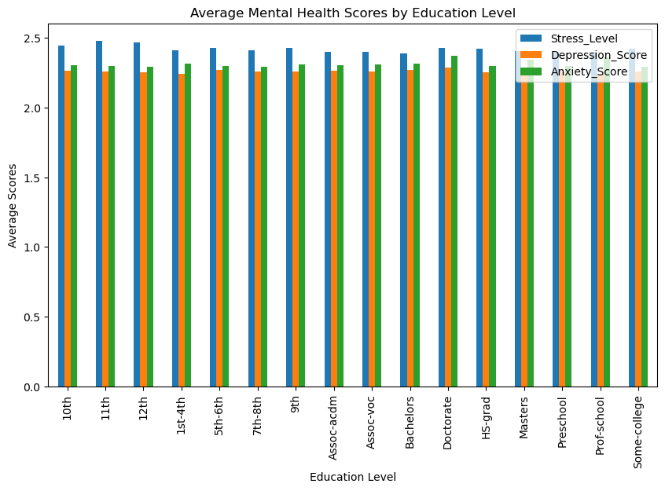

```python
education_mental_health = merged_df.groupby('education')[['Stress_Level', 'Depression_Score', 'Anxiety_Score']].mean()
print("Average Mental Health Scores by Education Level:\n", education_mental_health)

# Visualization for Q1 (Optional)
education_mental_health.plot(kind='bar', figsize=(10, 6))
plt.title('Average Mental Health Scores by Education Level')
plt.xlabel('Education Level')
plt.ylabel('Average Scores')
plt.show()
```

Based on the average mental health scores across different education levels:

- Stress Level: Generally, stress levels show slight variations among different education levels. Individuals with advanced degrees like Masters, Doctorate, or Prof-school tend to report slightly lower stress levels compared to those with lower educational attainment (e.g., 10th to 12th grade).
- Depression Score: There doesn't appear to be a significant difference in depression scores across various education levels. The scores remain relatively consistent across most categories of education.
- Anxiety Score: Similar to stress levels, anxiety scores exhibit minor differences across education levels. Individuals with higher education levels (Masters, Doctorate, Prof-school) generally report slightly higher anxiety scores compared to those with lower levels of education.

Overall, while there are discernible differences, the variations in mental health scores based on education level are relatively subtle. This suggests that educational attainment alone may not strongly correlate with mental health outcomes within this dataset.

### Q2: Influence of financial stress and annual income on academic performance and mental health

```
Financial Stress and Mental Health vs. Income:
                Financial_Stress      CGPA  Stress_Level  Depression_Score  \
annual_income
<=50K                  2.454513  3.489794      2.422073          2.259280
>50K                   2.459783  3.492650      2.404570          2.274613

               Anxiety_Score
annual_income
<=50K               2.299761
>50K                2.336411
```

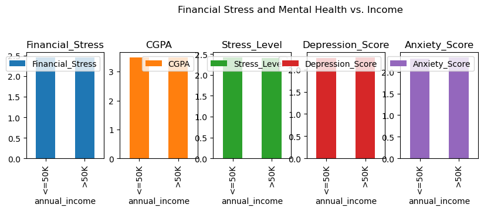

```python
income_mental_health_academics = merged_df.groupby('annual_income')[['Financial_Stress', 'CGPA', 'Stress_Level', 'Depression_Score', 'Anxiety_Score']].mean()
print("Financial Stress and Mental Health vs. Income:\n", income_mental_health_academics)

# Visualization for Q2 (Optional)
income_mental_health_academics.plot(kind='bar', figsize=(12, 8), subplots=True, layout=(3, 6))
plt.suptitle('Financial Stress and Mental Health vs. Income')
plt.show()
```

### **5.2:** Reflection

In 2-4 sentences, if you had more time to complete the project, what actions would you take? For example, which data quality and structural issues would you look into further, and what research questions would you further explore?

I'm interested in delving deeper into my research questions, particularly looking at how specific demographic factors such as age and gender correlate with mental health outcomes. Additionally, I plan to conduct temporal analysis to see how these relationships might change or develop over time.

```python
# Running this cell will execute a bash command to convert this notebook to an .html file
!python -m nbconvert --to html DataAnalysis.ipynb
```

```
[NbConvertApp] Converting notebook DataAnalysis.ipynb to html
[NbConvertApp] WARNING | Alternative text is missing on 7 image(s).
[NbConvertApp] Writing 672431 bytes to DataAnalysis.html
```